# static sequenceSniffer

Anne Rutten

February 1, 2020

static version of the duplicated-n-gram-flagging example. Easier to copy functionality out of.

## aim:

flag data points that are part of a sequence that is present at least twice in a given data set.

### `findDuplicates()`: identify duplicated sequences in a dataset

- works on data vectors (e.g., a dataframe column in ‘long’ format)
- function generates n-grams for given vector, iteratively increasing the sequence length from the specified `min_length` until no more duplicate n-grams are present in the data
- data points that are part of an n-gram that is present in the data more than once are marked with an identifier specific to the sequence

#### please note:

- the function does not yet check for overlapping sequences within a specific n-gram length, i.e. a sequence “A A B A A B A” will count and mark n-gram “A A B A” as duplicated
- longer sequences will overwrite shorter sequences that they overlap with, i.e., in the above example,3-gram “A B A” will be overwritten by 4-gram “A A B A”.

### usage:

*either just copy the `findDuplicates` function and run it inside your script, or

1. change the constants below and
2. knit this document to generate a report for a specific datafile

#### dependencies

```r
library(tidyverse)
library(ngram)
library(shiny)
library(DT)
library(colorspace)
library(ggplot2)
```

#### controls

```r
# path to csv datafile
fn <- "/home/anne/Pardosa_mesocosm_activity_P_R.csv"

# column range of the focal data (including)

fromColumn <- 3
toColumn <- 10

# minimum sequence length to consider

minLength <- 6

# if you want to reorder datapoints within some group and analyze the distribution of 'number of datapoints in duplicated sequences' in your dataset, specify grouping variable here
# the variable name that is assigned to the `names of the long` concatenated columns specified above is 'key'
groupingVars <-c("Treatment", "key")
```

#### ducttape-and-tiewraps wrapper around ngram::ngrams()

- somevector: vector of values that needs to be tested for repeat sequences
- min_length: the minimum sequence length
- sep: in case this is a vector of strings, some separator that is not present in the data itself

```r
findDuplicates <- function(somevector, min_length, sep=" ") {
  # paste all values into one string for n-gram calculation
  values_as_string <- paste(somevector, collapse= sep)

  # input data has to be coverted to character as well
  charactervector <- as.character(somevector)
  output <- data.frame(value=somevector, seqID = NA)
  done <- FALSE
  i <- min_length
  while (!done) {
    duplicates <- get.phrasetable(ngram(values_as_string, i)) %>%
                   filter(freq>1) %>%
                   select(ngrams) %>%
                   mutate(ngrams = strsplit(ngrams, sep))
    if (nrow(duplicates) > 0) {
      for(k in 1:nrow(duplicates)) {
        ng <- duplicates$ngrams[[k]]
        idx <- which(charactervector == ng[1])
        seqStart <- idx[sapply(idx, function(j) all(charactervector[j:(j+(length(ng)-1))] == ng))]
        output$seqID[rep(seqStart, each = i) + 0:(i-1)] <-paste0("n",i,"Seq",k)
     }
    i<-i+1
    } else done=TRUE
  }
  output$seqID
}
```

#### raw data:

|  | Replicate_ID | Treatment | Pardosa_1 | Pardosa_2 | Pardosa_3 | Pardosa_4 | Pardosa_5 | Pardosa_6 | Pardosa_7 | Pardosa_8 | mean_activity |
| --- | --- | --- | --- | --- | --- | --- | --- | --- | --- | --- | --- |
| 1 | 1 | Inactive | 7 | 7 | 8 | 8 | 4 | 2 | 8 | 8 | 6.5 |
| 2 | 2 | Inactive | 8 | 6 | 11 | 6 | 9 | 8 | 7 | 7 | 7.75 |
| 3 | 3 | Inactive | 4 | 8 | 13 | 8 | 8 | 3 | 8 | 8 | 7.5 |
| 4 | 4 | Inactive | 7 | 11 | 12 | 6 | 11 | 7 | 6 | 7 | 8.375 |
| 5 | 5 | Inactive | 8 | 5 | 13 | 3 | 13 | 4 | 8 | 11 | 8.125 |
| 6 | 6 | Inactive | 12 | 7 | 7 | 8 | 7 | 8 | 7 | 13 | 8.625 |
| 7 | 7 | Inactive | 7 | 4 | 2 | 6 | 11 | 5 | 12 | 9 | 7 |
| 8 | 8 | Inactive | 5 | 9 | 8 | 7 | 8 | 7 | 11 | 7 | 7.75 |
| 9 | 9 | Inactive | 8 | 8 | 3 | 5 | 13 | 5 | 8 | 8 | 7.25 |
| 10 | 10 | Inactive | 6 | 11 | 7 | 8 | 13 | 3 | 7 | 12 | 8.375 |

[output cut: 35 more lines]

#### data summary:

- `key`: column within specified column range
- `cardinality`: number of unique data values (less meaningful for `double` type, but who knows)
- `max_rle`: the maximum length of a single repeated value in a column
- `max_rle_at`: (if `max_rle`>1), the value(s) that has/have the `max_rle` (e.g. default values, censored data: many duplicate n-grams expected there)

-> many duplicates in a variable with low `n_distinct_levels` is to be expected.

-> many duplicates in a variable with a high `max_rle` are to be expected

|  | key | cardinality | max_rle | max_rle_at_level | n_duplicates | n_total | fraction |
| --- | --- | --- | --- | --- | --- | --- | --- |
| 1 | Pardosa_1 | 21 | 1 |  | 22 | 45 | 0.49 |
| 2 | Pardosa_2 | 20 | 1 |  | 32 | 45 | 0.71 |
| 3 | Pardosa_3 | 21 | 1 |  | 22 | 45 | 0.49 |
| 4 | Pardosa_4 | 19 | 1 |  | 28 | 45 | 0.62 |
| 5 | Pardosa_5 | 20 | 2 | 13 | 23 | 45 | 0.51 |
| 6 | Pardosa_6 | 21 | 2 | 18 | 32 | 45 | 0.71 |
| 7 | Pardosa_7 | 20 | 2 | 23 | 17 | 45 | 0.38 |
| 8 | Pardosa_8 | 19 | 1 |  | 15 | 45 | 0.33 |

#### detected sequences:

|  | Replicate_ID | Treatment | mean_activity | originalRowID | value_Pardosa_1 | value_Pardosa_2 | value_Pardosa_3 | value_Pardosa_4 | value_Pardosa_5 | value_Pardosa_6 | value_Pardosa_7 | value_Pardosa_8 | ngramID_Pardosa_1 | ngramID_Pardosa_2 | ngramID_Pardosa_3 | ngramID_Pardosa_4 | ngramID_Pardosa_5 | ngramID_Pardosa_6 | ngramID_Pardosa_7 | ngramID_Pardosa_8 |
| --- | --- | --- | --- | --- | --- | --- | --- | --- | --- | --- | --- | --- | --- | --- | --- | --- | --- | --- | --- | --- |
| 1 | 1 | Inactive | 6.5 | 1 | 7 | 7 | 8 | 8 | 4 | 2 | 8 | 8 |  | n6Seq12 |  |  | n6Seq16 | n9Seq16 |  |  |
| 2 | 2 | Inactive | 7.75 | 2 | 8 | 6 | 11 | 6 | 9 | 8 | 7 | 7 |  | n6Seq12 |  |  | n6Seq16 | n14Seq1 |  |  |
| 3 | 3 | Inactive | 7.5 | 3 | 4 | 8 | 13 | 8 | 8 | 3 | 8 | 8 |  | n6Seq12 |  |  | n6Seq16 | n14Seq1 |  | n9Seq7 |
| 4 | 4 | Inactive | 8.375 | 4 | 7 | 11 | 12 | 6 | 11 | 7 | 6 | 7 |  | n6Seq12 |  |  | n6Seq16 | n14Seq1 |  | n9Seq7 |
| 5 | 5 | Inactive | 8.125 | 5 | 8 | 5 | 13 | 3 | 13 | 4 | 8 | 11 |  |  |  |  | n6Seq16 | n14Seq1 |  | n9Seq7 |
| 6 | 6 | Inactive | 8.625 | 6 | 12 | 7 | 7 | 8 | 7 | 8 | 7 | 13 |  |  |  |  | n6Seq16 | n14Seq1 |  | n9Seq7 |
| 7 | 7 | Inactive | 7 | 7 | 7 | 4 | 2 | 6 | 11 | 5 | 12 | 9 |  | n6Seq16 | n9Seq16 |  |  | n14Seq1 |  | n9Seq7 |
| 8 | 8 | Inactive | 7.75 | 8 | 5 | 9 | 8 | 7 | 8 | 7 | 11 | 7 |  | n6Seq16 | n9Seq16 | n8Seq17 |  | n14Seq1 |  | n9Seq7 |
| 9 | 9 | Inactive | 7.25 | 9 | 8 | 8 | 3 | 5 | 13 | 5 | 8 | 8 |  | n6Seq16 | n9Seq16 | n8Seq17 |  | n14Seq1 |  | n9Seq7 |
| 10 | 10 | Inactive | 8.375 | 10 | 6 | 11 | 7 | 8 | 13 | 3 | 7 | 12 |  | n6Seq16 | n9Seq16 | n8Seq17 |  | n14Seq1 |  | n9Seq7 |

[output cut: 35 more lines]

### expected datapoints-in-duplicated-sequences distribution for this dataset:

- randomly reorder datapoints within Treatment, key (`key` contains the names of the column range specified by `fromCol` and `toCol`)
- calculate number of datapoints in recurring sequences
- repeat 1000 times

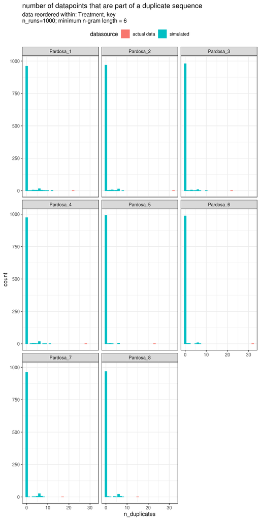